# MxMonks Final

Liz Hobson

July 17, 2017

## Load libraries

[output not shown]

## Import parsed trade & citizen science data

Set location for getting data

```r
LOC.finaldata <- "C:/Users/ehobs/Dropbox/P-monk MX invasion/MX-Monks/PLOSONE_FINAL_DATA/"

#NEW CITES DATA:CITES-new28Feb
cites <- read.csv(file=paste(LOC.finaldata, "cites_imports.csv", sep=""))

dgvs <- read.csv(file=paste(LOC.finaldata, "dgvs_imports.csv", sep=""))

citsci <- read.csv(file=paste(LOC.finaldata, "citizen_science_reports.csv", sep=""))

# add dummy shipment counter to DGVS data
dgvs$shipment.counter <- 1
dgvs$shipment.counter[dgvs$year==2015] <- 0
# check

str(cites)
```

```
## 'data.frame':    30 obs. of  9 variables:
##  $ Year                      : int  1981 1982 1994 1995 1999 1999 2000 2001 2004 2005 ...
##  $ Taxon                     : Factor w/ 1 level "Myiopsitta monachus": 1 1 1 1 1 1 1 1 1 1 ...
##  $ Importer                  : Factor w/ 1 level "MX": 1 1 1 1 1 1 1 1 1 1 ...
##  $ Exporter                  : Factor w/ 4 levels "AR","BE","PY",..: 1 1 2 2 1 3 3 3 1 1 ...
##  $ Importer.reported.quantity: int  NA NA 10 5 500 652 100 300 500 1000 ...
##  $ Exporter.reported.quantity: int  235 100 2 5 500 652 100 300 NA 1000 ...
##  $ Term                      : Factor w/ 1 level "live": 1 1 1 1 1 1 1 1 1 1 ...
##  $ Purpose                   : logi  TRUE TRUE TRUE TRUE TRUE TRUE ...
##  $ Source                    : Factor w/ 5 levels "","C","O","R",..: 1 1 2 2 5 5 5 5 5 5 ...
```

```r
str(dgvs)
```

```
## 'data.frame':    371 obs. of  4 variables:
##  $ year            : int  2000 2001 2002 2002 2004 2004 2005 2005 2006 2006 ...
##  $ quantity        : int  100 300 180 180 500 500 500 500 350 1000 ...
##  $ origin.country  : Factor w/ 4 levels "","ARGENTINA",..: 3 3 3 3 2 2 2 2 2 4 ...
##  $ shipment.counter: num  1 1 1 1 1 1 1 1 1 1 ...
```

```r
str(citsci)
```

```
## 'data.frame':    1854 obs. of  8 variables:
##  $ date          : Factor w/ 614 levels "1999-11-29","2005-12-11",..: 1 2 3 4 5 6 7 8 9 10 ...
##  $ latitude      : num  20.6 19.3 19.3 19.3 19.3 ...
##  $ longitude     : num  -105.2 -99.1 -99.1 -99.1 -99.1 ...
##  $ userID        : Factor w/ 296 levels "adeuksom","adrianaangulo",..: 169 205 63 128 73 93 43 5 205 77 ...
##  $ num.mymon.obsd: int  1 1 NA 6 NA NA NA NA 6 4 ...
##  $ city          : Factor w/ 93 levels "Aguascalientes",..: 62 51 51 51 51 61 37 51 51 51 ...
##  $ state         : Factor w/ 25 levels "Aguascalientes",..: 12 14 14 14 14 19 20 14 14 14 ...
##  $ region        : Factor w/ 4 levels "Baja","Central",..: 4 2 2 2 2 2 2 2 2 2 ...
```

## SUMMARIZE CITES DATA

```r
# summarize number imported indivs X reporter type per year, per purpose
grouped.MX <- group_by(cites, Year)
cites.summXyear <- as.data.frame(summarise(grouped.MX,
                                            CITESindivsXIMreps=sum(Importer.reported.quantity, na.rm=TRUE),
                                            CITESindivsXEXreps=sum(Exporter.reported.quantity, na.rm=TRUE)
                                            ))

cites.summXyear <- arrange(cites.summXyear, Year)
str(cites.summXyear)
```

```
## 'data.frame':    18 obs. of  3 variables:
##  $ Year              : int  1981 1982 1994 1995 1999 2000 2001 2004 2005 2006 ...
##  $ CITESindivsXIMreps: int  0 0 10 5 1152 100 300 500 1000 13490 ...
##  $ CITESindivsXEXreps: int  235 100 2 5 1152 100 300 0 1000 13840 ...
```

```r
cites.summXyear$CITESmin.rep <- pmin(cites.summXyear$CITESindivsXIMreps, cites.summXyear$CITESindivsXEXreps) # return minimum reported import quantity
cites.summXyear$CITESmax.rep <- pmax(cites.summXyear$CITESindivsXIMreps, cites.summXyear$CITESindivsXEXreps) # return maximum reported import quantity
cites.summXyear$CITESdiff.reps <- cites.summXyear$CITESmax.rep - cites.summXyear$CITESmin.rep # return difference between maximum and minimum reported import quantity
```

# set up blank dataframe to fill with answers to summary questions

Want historical perspective on CITES data that we can’t get from DGVS

```r
q3 <- cbind("q3", "what is max difference between importer and exporter reports?","CITES",
      max(cites.summXyear$CITESdiff.reps))

q3b <- cbind("q3b", "what is total diff btw importer and exporter report #s?","CITES",
      sum(cites.summXyear$CITESindivsXIMreps) - sum(cites.summXyear$CITESindivsXEXreps))


q1 <- cbind("q1", "#individuals total were imported for whole dataset? (IMrep)","CITES",
sum(cites$Importer.reported.quantity, na.rm=TRUE))

q2 <- cbind("q2", "#individuals total were imported for whole dataset? (EXrep)","CITES",
sum(cites$Exporter.reported.quantity, na.rm=TRUE))

q4 <- cbind("q4", "what is difference between importer reports & exporter reports in # indivs? (from raw df)","CITES",
            sum(cites$Importer.reported.quantity, na.rm=TRUE) - sum(cites$Exporter.reported.quantity, na.rm=TRUE))

q5 <- cbind("q5", "what is difference between IM&EX reports in # indivs? (summ df)","CITES",
sum(cites.summXyear$CITESindivsXIMreps) - sum(cites.summXyear$CITESindivsXEXreps)) #check, this and q4 should be same

q6a <- cbind("q6a", "imported reports are xx% of exported reports? (raw df)","CITES",
  round(sum(cites$Importer.reported.quantity, na.rm=TRUE) / sum(cites$Exporter.reported.quantity, na.rm=TRUE) *100,0))

q6b <- cbind("q6b", "imported reports are xx% of exported reports? (fr summ df)","CITES",
round((sum(cites.summXyear$CITESindivsXIMreps) / sum(cites.summXyear$CITESindivsXEXreps)) *100, 0))

q7 <- cbind("q7", "what year (1975-2015) did first imports occur?","CITES",
min(cites$Year, na.rm=TRUE))

q8 <- cbind("q8", "what year (1975-2015) did last imports occur?","CITES",
max(cites$Year, na.rm=TRUE))

# find earlier imports, before 2000 (ie to end of 1999)
cites.b42000 <- subset(cites, Year<2000)

q9 <- cbind("q9", "#indivs commercially imported b4 2000 (ie by end of 1999? (IM.reported)","CITES",
sum(cites.b42000$Importer.reported.quantity, na.rm=TRUE))

q10 <- cbind("q10", "#indivs commercially imported b4 2000 (ie by end of 1999? (EX.reported)","CITES",
sum(cites.b42000$Exporter.reported.quantity, na.rm=TRUE))

q10a <- cbind("q10a", "%indivs commercially imported b4 2000 (ie by end of 1999? (IN.reported)","CITES",
round(
  (sum(cites.b42000$Importer.reported.quantity, na.rm=TRUE)/sum(cites.summXyear$CITESindivsXIMreps))*100,2)
)

q10b <- cbind("q10b", "%indivs commercially imported b4 2000 (ie by end of 1999? (EX.reported)","CITES",
round(
  (sum(cites.b42000$Exporter.reported.quantity, na.rm=TRUE)/sum(cites.summXyear$CITESindivsXEXreps))*100,2)
)

q10c <- cbind("q10c", "what % of indivs imported btw start2008-end 2015? (IM.rep)","CITES",
round((sum(cites.summXyear$CITESindivsXIMreps[cites.summXyear$Year>2007]) / sum(cites.summXyear$CITESindivsXIMreps)) *100,0))

q11 <- cbind("q11", "what % of indivs imported between 2008-end 2015? (EX.rep)","CITES",
round((sum(cites.summXyear$CITESindivsXEXreps[cites.summXyear$Year>2007]) / sum(cites.summXyear$CITESindivsXEXreps)) *100,0))

q11a <- cbind("q11a", "how many indivs imported 2000-end 2015? (IM.rep)","CITES",
sum(cites.summXyear$CITESindivsXIMreps[cites.summXyear$Year>1999]))

q11b <- cbind("q11b", "how many indivs imported 2000-end 2015? (EX.rep)","CITES",
sum(cites.summXyear$CITESindivsXEXreps[cites.summXyear$Year>1999]))
```

### get total # individuals from each exporting country to MX for live commercial exports

```r
grouped.origins <- group_by(cites, Year, Exporter)
cites.summXcountryXyear <- as.data.frame(summarise(grouped.origins,
                                            nindivsXimporterreps=sum(Importer.reported.quantity, na.rm=TRUE),
                                            nindivsXexporterreps=sum(Exporter.reported.quantity, na.rm=TRUE)
                                            ))
```

### of TOTAL historical exports (commercial/live to MX, CITES), what % individuals came from each exporting country?

```r
grouped.origins2 <- group_by(cites, Exporter)
cites.summXcountry <- as.data.frame(summarise(grouped.origins2,
                                            nindivsXimporterreps=sum(Importer.reported.quantity, na.rm=TRUE),
                                            nindivsXexporterreps=sum(Exporter.reported.quantity, na.rm=TRUE)
                                            ))

cites.summXcountry$percent.indivs.exportedIMreps <- round((cites.summXcountry$nindivsXimporterreps / sum(cites.summXcountry$nindivsXimporterreps)*100),0)
cites.summXcountry$percent.indivs.exportedEXreps <- round((cites.summXcountry$nindivsXexporterreps / sum(cites.summXcountry$nindivsXexporterreps)*100),0)
as.data.frame(t(cites.summXcountry))
```

```
##                                   V1     V2     V3     V4
## Exporter                          AR     BE     PY     UY
## nindivsXimporterreps           16186     15   1052 574060
## nindivsXexporterreps           14401      7   1052 516210
## percent.indivs.exportedIMreps      3      0      0     97
## percent.indivs.exportedEXreps      3      0      0     97
```

### how many unique countries were commercial/live exporters to MX?

```r
unique(cites$Exporter)
```

```
## [1] AR BE PY UY
## Levels: AR BE PY UY
```

```r
length(unique(cites$Exporter))
```

```
## [1] 4
```

### More import questions

```r
str(cites.summXcountry)
```

```
## 'data.frame':    4 obs. of  5 variables:
##  $ Exporter                     : Factor w/ 4 levels "AR","BE","PY",..: 1 2 3 4
##  $ nindivsXimporterreps         : int  16186 15 1052 574060
##  $ nindivsXexporterreps         : int  14401 7 1052 516210
##  $ percent.indivs.exportedIMreps: num  3 0 0 97
##  $ percent.indivs.exportedEXreps: num  3 0 0 97
```

```r
q12 <- cbind("q12", "#indivs that originated from Uruguay for whole history? (IM.rep)", "CITES",
cites.summXcountry$nindivsXimporterreps[cites.summXcountry$Exporter=="UY"])

q13 <- cbind("q13", "#indivs that originated from Uruguay for whole history? (EX.rep)", "CITES",
cites.summXcountry$nindivsXexporterreps[cites.summXcountry$Exporter=="UY"])

q14 <- cbind("q14", "diff btw IM&EX #indivs from Uruguay whole history?", "CITES",
cites.summXcountry$nindivsXimporterreps[cites.summXcountry$Exporter=="UY"] - cites.summXcountry$nindivsXexporterreps[cites.summXcountry$Exporter=="UY"])

q15 <- cbind("q15", "diff % IMvsEX #indivs from Uruguay whole history?", "CITES",
round((cites.summXcountry$nindivsXimporterreps[cites.summXcountry$Exporter=="UY"] / cites.summXcountry$nindivsXexporterreps[cites.summXcountry$Exporter=="UY"])*100,0)
)
```

# SUMMARIZE DGVS DATA

### summary questions: number individuals imported (data from DGVS)

```r
q16 <- cbind("q16", "#individuals total commercially imported (whole dataset)?", "DGVS",
sum(dgvs$quantity))

q17 <- cbind("q17", "between which years? start", "DGVS",
min(dgvs$year))

q18 <- cbind("q18", "between which years? end", "DGVS",
max(dgvs$year))

#subset, find data start 2008 to end 2015
DGVS.2008to2015 <- subset(dgvs, year>2007)

q19 <- cbind("q19", "how many individuals total were imported beginning 2008 to end 2015?", "DGVS",
sum(DGVS.2008to2015$quantity))

q20 <- cbind("q20", "what % of total imported individuals were imported between 2008 and end of 2014?", "DGVS",
round((sum(DGVS.2008to2015$quantity) / sum(dgvs$quantity)) *100,0))
```

## summarize # shipments imported

```r
q22 <- cbind("q22", "how many commercial shipments total were imported 1999 to 2015?", "DGVS",
sum(dgvs$shipment.counter))

q23 <- cbind("q23", "how many shipments total were imported beginning 2008 to end of 2015?", "DGVS",
sum(DGVS.2008to2015$shipment.counter))

q24 <- cbind("q24", "what % of total imported individuals were imported between 2008 and end of 2014?", "DGVS",
round((sum(DGVS.2008to2015$shipment.counter) / sum(dgvs$shipment.counter)) *100,0))
```

## summarize # indivs X year, # shipments X year

```r
str(DGVS.2008to2015)
```

```
## 'data.frame':    325 obs. of  4 variables:
##  $ year            : int  2008 2008 2008 2008 2008 2008 2008 2008 2008 2008 ...
##  $ quantity        : int  1200 1500 1500 1400 1400 1400 1500 1500 1500 1400 ...
##  $ origin.country  : Factor w/ 4 levels "","ARGENTINA",..: 4 4 4 4 4 4 4 4 4 4 ...
##  $ shipment.counter: num  1 1 1 1 1 1 1 1 1 1 ...
```

```r
str(dgvs)
```

```
## 'data.frame':    371 obs. of  4 variables:
##  $ year            : int  2000 2001 2002 2002 2004 2004 2005 2005 2006 2006 ...
##  $ quantity        : int  100 300 180 180 500 500 500 500 350 1000 ...
##  $ origin.country  : Factor w/ 4 levels "","ARGENTINA",..: 3 3 3 3 2 2 2 2 2 4 ...
##  $ shipment.counter: num  1 1 1 1 1 1 1 1 1 1 ...
```

```r
# get total # individuals and # shipments from each exporting country to MX for live commercial exports
G.origins <- group_by(dgvs, year, origin.country)
DGVS.shipsXcountryXyr <- as.data.frame(summarise(G.origins, total.shipments=sum(shipment.counter), total.indivs=sum(quantity)))


q25 <- cbind("q25", "how many unique countries were commercial/live exporters to MX? (country of origin) (2000-2015)", "DGVS",
length(unique(DGVS.shipsXcountryXyr$origin.country)))

unique(DGVS.shipsXcountryXyr$origin.country)
```

```
## [1] PARAGUAY  ARGENTINA URUGUAY
## Levels:  ARGENTINA PARAGUAY URUGUAY
```

```r
str(DGVS.shipsXcountryXyr)
```

```
## 'data.frame':    19 obs. of  4 variables:
##  $ year           : int  2000 2001 2002 2004 2005 2006 2006 2007 2007 2008 ...
##  $ origin.country : Factor w/ 4 levels "","ARGENTINA",..: 3 3 3 2 2 2 4 2 4 4 ...
##  $ total.shipments: num  1 1 2 2 2 4 6 2 26 25 ...
##  $ total.indivs   : int  100 300 360 1000 1000 1990 11500 1130 36900 36300 ...
```

### of TOTAL DGVS-reported imports (commercial/live to MX), what % individuals came from each exporting country (2000-2015)?

```r
grouped.exports.DGVS <- group_by(DGVS.shipsXcountryXyr, origin.country)
DGVS.shipsXcountry <- as.data.frame(summarise(grouped.exports.DGVS, total.shipments=sum(total.shipments), total.indivs=sum(total.indivs)))
DGVS.shipsXcountry$percent.indivs.exported <- round((DGVS.shipsXcountry$total.indivs / sum(DGVS.shipsXcountry$total.indivs)*100),0)
DGVS.shipsXcountry$percent.ships.exported <- round((DGVS.shipsXcountry$total.shipments / sum(DGVS.shipsXcountry$total.shipments)*100),0)
str(DGVS.shipsXcountry)
```

```
## 'data.frame':    4 obs. of  5 variables:
##  $ origin.country         : Factor w/ 4 levels "","ARGENTINA",..: 1 2 3 4
##  $ total.shipments        : num  0 17 4 349
##  $ total.indivs           : int  0 16186 760 566100
##  $ percent.indivs.exported: num  0 3 0 97
##  $ percent.ships.exported : num  0 5 1 94
```

### of TOTAL start 2008- end 2015 exports (commercial/live to MX), what % individuals came from each exporting country?

```r
DGVS.export.countries.2008to2015 <- subset(DGVS.shipsXcountryXyr, year>2007 & total.shipments>0) #exclude the dummy "0" shipment without origin country
str(DGVS.export.countries.2008to2015)
```

```
## 'data.frame':    9 obs. of  4 variables:
##  $ year           : int  2008 2009 2010 2011 2011 2012 2012 2013 2014
##  $ origin.country : Factor w/ 4 levels "","ARGENTINA",..: 4 4 4 2 4 2 4 4 4
##  $ total.shipments: num  25 48 53 5 44 2 74 64 9
##  $ total.indivs   : int  36300 67560 88540 8866 71800 2200 126800 111700 15000
```

```r
Gr.exports.DGVS.2008to2015 <- group_by(DGVS.export.countries.2008to2015, origin.country)
DGVS.export.countries.2008to2015.summ <- as.data.frame(summarise(Gr.exports.DGVS.2008to2015, total.shipments=sum(total.shipments), total.indivs=sum(total.indivs)))

DGVS.export.countries.2008to2015.summ$percent.indivs.exported <- round((DGVS.export.countries.2008to2015.summ$total.indivs / sum(DGVS.export.countries.2008to2015.summ$total.indivs)*100),0)

DGVS.export.countries.2008to2015.summ$percent.ships.exported <- round((DGVS.export.countries.2008to2015.summ$total.shipments / sum(DGVS.export.countries.2008to2015.summ$total.shipments)*100),0)

str(DGVS.export.countries.2008to2015.summ)
```

```
## 'data.frame':    2 obs. of  5 variables:
##  $ origin.country         : Factor w/ 4 levels "","ARGENTINA",..: 2 4
##  $ total.shipments        : num  7 317
##  $ total.indivs           : int  11066 517700
##  $ percent.indivs.exported: num  2 98
##  $ percent.ships.exported : num  2 98
```

### get total # individuals and # shipments from across all exporting countrys to MX for live commercial exports

```r
G.nindivsXyear <- group_by(dgvs, year)
DGVS.nindivsXyear <- as.data.frame(summarise(G.nindivsXyear, total.DGVS.shipments=sum(shipment.counter), total.DGVS.total.indivs=sum(quantity)))
str(DGVS.nindivsXyear)
```

```
## 'data.frame':    15 obs. of  3 variables:
##  $ year                   : int  2000 2001 2002 2004 2005 2006 2007 2008 2009 2010 ...
##  $ total.DGVS.shipments   : num  1 1 2 2 2 10 28 25 48 53 ...
##  $ total.DGVS.total.indivs: int  100 300 360 1000 1000 13490 38030 36300 67560 88540 ...
```

## Compile trade data DGVS + CITES

```r
str(cites.summXyear)
```

```
## 'data.frame':    18 obs. of  6 variables:
##  $ Year              : int  1981 1982 1994 1995 1999 2000 2001 2004 2005 2006 ...
##  $ CITESindivsXIMreps: int  0 0 10 5 1152 100 300 500 1000 13490 ...
##  $ CITESindivsXEXreps: int  235 100 2 5 1152 100 300 0 1000 13840 ...
##  $ CITESmin.rep      : int  0 0 2 5 1152 100 300 0 1000 13490 ...
##  $ CITESmax.rep      : int  235 100 10 5 1152 100 300 500 1000 13840 ...
##  $ CITESdiff.reps    : int  235 100 8 0 0 0 0 500 0 350 ...
```

```r
str(DGVS.nindivsXyear)
```

```
## 'data.frame':    15 obs. of  3 variables:
##  $ year                   : int  2000 2001 2002 2004 2005 2006 2007 2008 2009 2010 ...
##  $ total.DGVS.shipments   : num  1 1 2 2 2 10 28 25 48 53 ...
##  $ total.DGVS.total.indivs: int  100 300 360 1000 1000 13490 38030 36300 67560 88540 ...
```

```r
TRADExYR.compiled <- merge(cites.summXyear, DGVS.nindivsXyear, by.x="Year", by.y="year", all=TRUE, fill=0)
#TRADExYR.compiled[is.na(TRADExYR.compiled)] <- 0
str(TRADExYR.compiled)
```

```
## 'data.frame':    20 obs. of  8 variables:
##  $ Year                   : int  1981 1982 1994 1995 1999 2000 2001 2002 2004 2005 ...
##  $ CITESindivsXIMreps     : int  0 0 10 5 1152 100 300 NA 500 1000 ...
##  $ CITESindivsXEXreps     : int  235 100 2 5 1152 100 300 NA 0 1000 ...
##  $ CITESmin.rep           : int  0 0 2 5 1152 100 300 NA 0 1000 ...
##  $ CITESmax.rep           : int  235 100 10 5 1152 100 300 NA 500 1000 ...
##  $ CITESdiff.reps         : int  235 100 8 0 0 0 0 NA 500 0 ...
##  $ total.DGVS.shipments   : num  NA NA NA NA NA 1 1 2 2 2 ...
##  $ total.DGVS.total.indivs: int  NA NA NA NA NA 100 300 360 1000 1000 ...
```

```r
TRADExYR.compiled$CITESindivsXIMreps[is.na(TRADExYR.compiled$CITESindivsXIMreps)] <- 0
TRADExYR.compiled$CITESindivsXEXreps[is.na(TRADExYR.compiled$CITESindivsXEXreps)] <- 0
TRADExYR.compiled$CITESmin.rep[is.na(TRADExYR.compiled$CITESmin.rep)] <- 0
TRADExYR.compiled$CITESmax.rep[is.na(TRADExYR.compiled$CITESmax.rep)] <- 0
TRADExYR.compiled$CITESdiff.reps[is.na(TRADExYR.compiled$CITESdiff.reps)] <- 0

TRADExYR.compiled$diffimportsDGVSxCITES.IM <- TRADExYR.compiled$total.DGVS.total.indivs - TRADExYR.compiled$CITESindivsXIMreps
TRADExYR.compiled$which.higher <- ifelse(TRADExYR.compiled$total.DGVS.total.indivs > TRADExYR.compiled$CITESindivsXIMreps, "DGVS higher", ifelse(TRADExYR.compiled$total.DGVS.total.indivs==TRADExYR.compiled$CITESindivsXIMreps, "same", ifelse(TRADExYR.compiled$total.DGVS.total.indivs<TRADExYR.compiled$CITESindivsXIMreps,"lower", "no data")))

TRADExYR.compiled$which.higher[is.na(TRADExYR.compiled$which.higher)] <- "NO DATA"

str(TRADExYR.compiled)
```

```
## 'data.frame':    20 obs. of  10 variables:
##  $ Year                    : int  1981 1982 1994 1995 1999 2000 2001 2002 2004 2005 ...
##  $ CITESindivsXIMreps      : num  0 0 10 5 1152 ...
##  $ CITESindivsXEXreps      : num  235 100 2 5 1152 ...
##  $ CITESmin.rep            : num  0 0 2 5 1152 ...
##  $ CITESmax.rep            : num  235 100 10 5 1152 ...
##  $ CITESdiff.reps          : num  235 100 8 0 0 0 0 0 500 0 ...
##  $ total.DGVS.shipments    : num  NA NA NA NA NA 1 1 2 2 2 ...
##  $ total.DGVS.total.indivs : int  NA NA NA NA NA 100 300 360 1000 1000 ...
##  $ diffimportsDGVSxCITES.IM: num  NA NA NA NA NA 0 0 360 500 0 ...
##  $ which.higher            : chr  "NO DATA" "NO DATA" "NO DATA" "NO DATA" ...
```

```r
#subset X year
TRADExYR.compiled.1999toend2015 <- subset(TRADExYR.compiled, Year>1998 & Year <2016)
TRADExYR.compiled.2000toend2015 <- subset(TRADExYR.compiled, Year>1999 & Year <2016)
TRADExYR.compiled.1999toend2014 <- subset(TRADExYR.compiled.1999toend2015, Year<2015)
```

# compare DGVS with CITES data

```r
q26 <- cbind("q26", "how many years did CITES imported-reported number match DGVS?", "DGVS v CITES.IM",
yrs.DGVS.same <- length(TRADExYR.compiled.2000toend2015$which.higher[TRADExYR.compiled.2000toend2015$which.higher=="same"]))
yrs.DGVS.same #number of years of match
```

```
## [1] 11
```

```r
total.yrs <- 2015-2000

q27 <- cbind("q27", "what % years did CITES imported-reported number match DGVS?", "DGVS v CITES.IM",
round(yrs.DGVS.same / total.yrs *100, 0))

q28 <- cbind("q28", "total imported individuals DGVS reported start 2000 to end 2015?", "DGVS",
total.DGVS <- sum(TRADExYR.compiled.2000toend2015$total.DGVS.total.indivs))
total.DGVS
```

```
## [1] 583046
```

```r
q28 <- cbind("q28", "total imported individuals CITES.IM reported start 2000 to end 2015?", "CITES.IM",
total.CITES.IM <- sum(TRADExYR.compiled.2000toend2015$CITESindivsXIMreps))
total.CITES.IM
```

```
## [1] 590146
```

```r
q29 <- cbind("q29", "what is total discrepancy: CITES-importer minus DGVS reported?", "DGVS v CITES.IM",
total.CITES.IM - total.DGVS)

q29a <- cbind("q29a", "what is total discrepancy: CITES-exporter(2000-2015) minus DGVS reported?", "DGVS v CITES.IM",
total.DGVS - sum(TRADExYR.compiled.2000toend2015$CITESindivsXEXreps))

q30 <- cbind("q30", "how many DGVS shipments occured start 2000 to end 2015?", "DGVS",
total.DGVS.shipments <- sum(TRADExYR.compiled.2000toend2015$total.shipments.DGVS))
total.DGVS.shipments
```

```
## [1] 0
```

## Compile summary of answers to trade questions

```r
summary <- as.data.frame(rbind(q1,q2,q3,q3b,q4,q5,q6a,q6b,q7,q8,q9,q10,q10a,q10b,q10c,q11,q11a,q11b,q13,q14,q15,q16,q17,q18,q19,q20,q22,q23,q24,q25,q26,q27,q28,q29, q30)) #exclude 12 and 21

colnames(summary) <- c("Qid", "question", "data", "answer")
summary
```

```
##     Qid
## 1    q1
## 2    q2
## 3    q3
## 4   q3b
## 5    q4
## 6    q5
## 7   q6a
## 8   q6b
## 9    q7
## 10   q8
## 11   q9
## 12  q10
## 13 q10a
## 14 q10b
```

[output cut: 93 more lines]

# SUMMARIZE CITIZEN SCIENCE REPORTS

```r
str(citsci)
```

```
## 'data.frame':    1854 obs. of  8 variables:
##  $ date          : Factor w/ 614 levels "1999-11-29","2005-12-11",..: 1 2 3 4 5 6 7 8 9 10 ...
##  $ latitude      : num  20.6 19.3 19.3 19.3 19.3 ...
##  $ longitude     : num  -105.2 -99.1 -99.1 -99.1 -99.1 ...
##  $ userID        : Factor w/ 296 levels "adeuksom","adrianaangulo",..: 169 205 63 128 73 93 43 5 205 77 ...
##  $ num.mymon.obsd: int  1 1 NA 6 NA NA NA NA 6 4 ...
##  $ city          : Factor w/ 93 levels "Aguascalientes",..: 62 51 51 51 51 61 37 51 51 51 ...
##  $ state         : Factor w/ 25 levels "Aguascalientes",..: 12 14 14 14 14 19 20 14 14 14 ...
##  $ region        : Factor w/ 4 levels "Baja","Central",..: 4 2 2 2 2 2 2 2 2 2 ...
```

```r
str(citsci)
```

```
## 'data.frame':    1854 obs. of  8 variables:
##  $ date          : Factor w/ 614 levels "1999-11-29","2005-12-11",..: 1 2 3 4 5 6 7 8 9 10 ...
##  $ latitude      : num  20.6 19.3 19.3 19.3 19.3 ...
##  $ longitude     : num  -105.2 -99.1 -99.1 -99.1 -99.1 ...
##  $ userID        : Factor w/ 296 levels "adeuksom","adrianaangulo",..: 169 205 63 128 73 93 43 5 205 77 ...
##  $ num.mymon.obsd: int  1 1 NA 6 NA NA NA NA 6 4 ...
##  $ city          : Factor w/ 93 levels "Aguascalientes",..: 62 51 51 51 51 61 37 51 51 51 ...
##  $ state         : Factor w/ 25 levels "Aguascalientes",..: 12 14 14 14 14 19 20 14 14 14 ...
##  $ region        : Factor w/ 4 levels "Baja","Central",..: 4 2 2 2 2 2 2 2 2 2 ...
```

```r
#set date as.Date
citsci$date <- as.Date(citsci$date)
citsci$year <- year(citsci$date)
citsci$report.dummy <- 1

############## Basic stats on full DB (good date/loc, pre-2016)
min(citsci$date) # what was date of first report in cit sci database?
```

```
## [1] "1999-11-29"
```

```r
max(citsci$date) # what was date of last report in cit sci database?
```

```
## [1] "2015-12-31"
```

```r
length(citsci$date) # how many reports were filed?
```

```
## [1] 1854
```

```r
length(unique(citsci$date)) # how many unique dates had reports?
```

```
## [1] 614
```

```r
citsci[which.min(citsci$date),] #extract earliest record
```

```
##         date latitude longitude     userID num.mymon.obsd            city
## 1 1999-11-29 20.64619 -105.2361 obsr381981              1 Puerto Vallarta
##     state region year report.dummy
## 1 Jalisco  South 1999            1
```

```r
# get list of all unique cities where monks observed before 2016
#(check city/state combos to make sure there aren't more "La Paz"s hiding, ie duplicate city names)
list.unique.citiesstates <- unique(citsci[c("city", "state")])
list.unique.cities <- unique(citsci$city)
list.unique.states <- unique(citsci$state)

#total number unique cities (should be same for both calls, and =93)
length(list.unique.citiesstates$city)
```

```
## [1] 93
```

```r
length(list.unique.cities)
```

```
## [1] 93
```

```r
# get list of average location of obs X city using [DATA.trim] & [list.unique.citiesstates]

G.locs <- group_by(citsci, city, state)
avg.city.loc.MASTER <- as.data.frame(summarise(G.locs, avg.cityLAT=mean(latitude), avg.cityLOG=mean(longitude)))
str(avg.city.loc.MASTER)
```

```
## 'data.frame':    93 obs. of  4 variables:
##  $ city       : Factor w/ 93 levels "Aguascalientes",..: 1 2 3 4 5 6 7 8 9 10 ...
##  $ state      : Factor w/ 25 levels "Aguascalientes",..: 1 12 12 7 25 13 24 17 25 20 ...
##  $ avg.cityLAT: num  21.9 20.7 20.3 28.3 18.8 ...
##  $ avg.cityLOG: num  -102.3 -104 -103.3 -100.9 -95.7 ...
```

```r
#find # unique cities X year
citsci.unique.citiesXyr <- unique(citsci[c("year", "city")])
citsci.unique.citiesXyr$dummy.unique.city <- 1
unique(is.na(citsci.unique.citiesXyr$city)) # should all be "FALSE" = no missing cities
```

```
## [1] FALSE
```

```r
#how many unique cities had reports per year?
grouped.citys <- group_by(citsci.unique.citiesXyr, year)
citsci.unique.citiesXyr.summ <- as.data.frame(summarise(grouped.citys, unique.cities=sum(dummy.unique.city)))
citsci.unique.citiesXyr.summ
```

```
##    year unique.cities
## 1  1999             1
## 2  2005             1
## 3  2006             1
## 4  2007             1
## 5  2008             3
## 6  2009             3
## 7  2010             7
## 8  2011             9
## 9  2012            22
## 10 2013            24
## 11 2014            37
## 12 2015            66
```

```r
#using dplyr, group obs X yr
grouped <- group_by(citsci, year)
citsci.reportsXyr <- as.data.frame(summarise(grouped, total.reports=sum(report.dummy)))
citsci.reportsXyr
```

```
##    year total.reports
## 1  1999             1
## 2  2005             1
## 3  2006             1
## 4  2007             2
## 5  2008             5
## 6  2009            38
## 7  2010            36
## 8  2011            27
## 9  2012            69
## 10 2013           179
## 11 2014           306
## 12 2015          1189
```

```r
#add unique reports X yr to unique cities X yr
citsciXYRxcityxreports <- cbind(citsci.reportsXyr, citsci.unique.citiesXyr.summ$unique.cities)
str(citsciXYRxcityxreports)
```

```
## 'data.frame':    12 obs. of  3 variables:
##  $ year                                      : num  1999 2005 2006 2007 2008 ...
##  $ total.reports                             : num  1 1 1 2 5 38 36 27 69 179 ...
##  $ citsci.unique.citiesXyr.summ$unique.cities: num  1 1 1 1 3 3 7 9 22 24 ...
```

```r
names(citsciXYRxcityxreports) <- c("year", "n.citsci.reports", "n.citsci.cities")
```

## add region data

```r
mx.states.atts <- read.table(file=paste(LOC.finaldata, "mx.states.attributes.txt", sep=""), stringsAsFactors = FALSE, sep = "\t", as.is=T,header=T)
str(mx.states.atts)
```

```
## 'data.frame':    32 obs. of  3 variables:
##  $ ord     : int  1 2 3 4 5 6 7 8 9 10 ...
##  $ state   : chr  "Aguascalientes" "Baja California" "Baja California Sur" "Campeche" ...
##  $ reg7.cat: chr  "North" "North Pacific" "North Pacific" "Yucatan" ...
```

```r
#import MX state names (with and without accents)
state.names <- read.csv("state.names.csv", sep = ",", as.is=T,header=T)
str(state.names)
```

```
## 'data.frame':    32 obs. of  3 variables:
##  $ reg7.cat       : chr  "North" "North Pacific" "North Pacific" "Yucatan" ...
##  $ state          : chr  "Aguascalientes" "Baja California" "Baja California Sur" "Campeche" ...
##  $ names.w.accents: chr  "Aguascalientes" "Baja California Sur" "Baja California" "Campeche" ...
```

```r
#import region MASTER
reg7.master <- read.csv(paste(LOC.finaldata, "reg7.master.csv", sep=""))
str(reg7.master)
```

```
## 'data.frame':    7 obs. of  3 variables:
##  $ reg7.cat : Factor w/ 7 levels "Central Highlands",..: 5 4 2 1 3 6 7
##  $ reg.order: int  1 2 3 4 5 6 7
##  $ col.names: Factor w/ 7 levels "blue","darkgoldenrod1",..: 4 2 6 5 1 3 7
```

```r
#merge state names with color X region
statesXregWcols <- merge(mx.states.atts, reg7.master, by="reg7.cat", all.x=T)
str(statesXregWcols)
```

```
## 'data.frame':    32 obs. of  5 variables:
##  $ reg7.cat : chr  "Central Highlands" "Central Highlands" "Central Highlands" "Central Highlands" ...
##  $ ord      : int  10 17 14 21 22 15 12 29 18 13 ...
##  $ state    : chr  "Guanajuato" "Morelos" "Mexico" "Puebla" ...
##  $ reg.order: int  4 4 4 4 4 4 4 4 3 3 ...
##  $ col.names: Factor w/ 7 levels "blue","darkgoldenrod1",..: 5 5 5 5 5 5 5 5 6 6 ...
```

```r
statesXregWcols <- merge(statesXregWcols, state.names, by=c("state", "reg7.cat"))
str(statesXregWcols)
```

```
## 'data.frame':    32 obs. of  6 variables:
##  $ state          : chr  "Aguascalientes" "Baja California Sur" "Baja California" "Campeche" ...
##  $ reg7.cat       : chr  "North" "North Pacific" "North Pacific" "Yucatan" ...
##  $ ord            : int  1 3 2 4 5 6 7 8 9 10 ...
##  $ reg.order      : int  2 1 1 7 6 2 2 3 2 4 ...
##  $ col.names      : Factor w/ 7 levels "blue","darkgoldenrod1",..: 2 4 4 7 3 2 2 6 2 5 ...
##  $ names.w.accents: chr  "Aguascalientes" "Baja California" "Baja California Sur" "Campeche" ...
```

```r
#merge state data with citizen science reports to summarize by region
DATA.reg7 <- merge(citsci, statesXregWcols, by="state", all.x=T)

str(DATA.reg7)
```

```
## 'data.frame':    1854 obs. of  15 variables:
##  $ state          : Factor w/ 25 levels "Aguascalientes",..: 1 1 1 1 1 1 2 2 2 2 ...
##  $ date           : Date, format: "2015-09-26" "2014-12-11" ...
##  $ latitude       : num  21.9 21.9 21.9 21.9 21.9 ...
##  $ longitude      : num  -102 -102 -102 -102 -102 ...
##  $ userID         : Factor w/ 296 levels "adeuksom","adrianaangulo",..: 251 224 224 1 224 251 240 240 228 207 ...
##  $ num.mymon.obsd : int  11 4 3 NA 4 2 8 1 20 1 ...
##  $ city           : Factor w/ 93 levels "Aguascalientes",..: 1 1 1 1 1 1 50 28 50 28 ...
##  $ region         : Factor w/ 4 levels "Baja","Central",..: 3 3 3 3 3 3 1 1 1 1 ...
##  $ year           : num  2015 2014 2015 2014 2014 ...
##  $ report.dummy   : num  1 1 1 1 1 1 1 1 1 1 ...
##  $ reg7.cat       : chr  "North" "North" "North" "North" ...
##  $ ord            : int  1 1 1 1 1 1 2 2 2 2 ...
##  $ reg.order      : int  2 2 2 2 2 2 1 1 1 1 ...
##  $ col.names      : Factor w/ 7 levels "blue","darkgoldenrod1",..: 2 2 2 2 2 2 4 4 4 4 ...
##  $ names.w.accents: chr  "Aguascalientes" "Aguascalientes" "Aguascalientes" "Aguascalientes" ...
```

```r
unique(is.na(DATA.reg7$reg7.cat)) #should all be false, no missing data
```

```
## [1] FALSE
```

## get # reports X city X year

```r
#how many citsci reports are there per year per NEW 7 region syst & city?
grouped.regionXcityXyr <- group_by(DATA.reg7, year, reg7.cat, city, state, reg.order)
reportsXyrXregionXcity <- as.data.frame(summarise(grouped.regionXcityXyr, total.obsXcityXyr=sum(report.dummy)))
str(reportsXyrXregionXcity)
```

```
## 'data.frame':    175 obs. of  6 variables:
##  $ year             : num  1999 2005 2006 2007 2008 ...
##  $ reg7.cat         : chr  "Central Pacific" "Central Highlands" "Central Highlands" "Central Highlands" ...
##  $ city             : Factor w/ 93 levels "Aguascalientes",..: 62 51 51 51 37 51 61 51 46 82 ...
##  $ state            : Factor w/ 25 levels "Aguascalientes",..: 12 14 14 14 20 14 19 14 3 5 ...
##  $ reg.order        : int  3 4 4 4 4 4 4 4 1 6 ...
##  $ total.obsXcityXyr: num  1 1 1 2 1 3 1 36 1 1 ...
```

```r
reportsXyrXregionXcity$dummy.XcityreportingXyr <- 1 #adds dummy to count # cities reporting PER YEAR
```

## how many monk cities are in each new region (7 regs)? NEW: FLIP DATA AROUND, region, state, city X years

```r
CAST.citiesXyrs <- dcast(data=reportsXyrXregionXcity, formula=reg7.cat+reg.order+state+city~year, value.var="total.obsXcityXyr", fill=0)
CAST.citiesXyrs <- arrange(CAST.citiesXyrs, reg.order, state, city)
```

### now melt

```r
str(CAST.citiesXyrs)
```

```
## 'data.frame':    93 obs. of  16 variables:
##  $ reg7.cat : chr  "North Pacific" "North Pacific" "North Pacific" "North Pacific" ...
##  $ reg.order: int  1 1 1 1 1 1 1 1 1 1 ...
##  $ state    : Factor w/ 25 levels "Aguascalientes",..: 2 2 3 3 3 3 3 21 22 22 ...
##  $ city     : Factor w/ 93 levels "Aguascalientes",..: 28 50 13 25 31 42 46 47 18 32 ...
##  $ 1999     : num  0 0 0 0 0 0 0 0 0 0 ...
##  $ 2005     : num  0 0 0 0 0 0 0 0 0 0 ...
##  $ 2006     : num  0 0 0 0 0 0 0 0 0 0 ...
##  $ 2007     : num  0 0 0 0 0 0 0 0 0 0 ...
##  $ 2008     : num  0 0 0 0 0 0 0 0 0 0 ...
##  $ 2009     : num  0 0 0 0 0 0 1 0 0 0 ...
##  $ 2010     : num  0 0 0 0 0 0 0 0 0 0 ...
##  $ 2011     : num  0 0 0 0 0 0 0 0 0 0 ...
##  $ 2012     : num  1 1 0 0 4 0 1 0 0 0 ...
##  $ 2013     : num  2 0 0 0 23 8 2 0 0 0 ...
##  $ 2014     : num  2 0 0 0 10 13 0 0 0 6 ...
##  $ 2015     : num  6 1 1 2 10 10 6 2 2 25 ...
```

```r
#melt(airquality, id.vars = c("month", "day"))
MELT.citiesXyrs <- melt(data=select(CAST.citiesXyrs, -reg7.cat, -reg.order), id.vars= c("state","city"), variable.name="year", value.name="num.reportsXcity")
str(MELT.citiesXyrs)
```

```
## 'data.frame':    1116 obs. of  4 variables:
##  $ state           : Factor w/ 25 levels "Aguascalientes",..: 2 2 3 3 3 3 3 21 22 22 ...
##  $ city            : Factor w/ 93 levels "Aguascalientes",..: 28 50 13 25 31 42 46 47 18 32 ...
##  $ year            : Factor w/ 12 levels "1999","2005",..: 1 1 1 1 1 1 1 1 1 1 ...
##  $ num.reportsXcity: num  0 0 0 0 0 0 0 0 0 0 ...
```

```r
MELT.citiesXyrs.no0s <- subset(MELT.citiesXyrs, num.reportsXcity>0)
str(MELT.citiesXyrs.no0s)
```

```
## 'data.frame':    175 obs. of  4 variables:
##  $ state           : Factor w/ 25 levels "Aguascalientes",..: 12 14 14 14 14 19 20 3 14 5 ...
##  $ city            : Factor w/ 93 levels "Aguascalientes",..: 62 51 51 51 51 61 37 46 51 82 ...
##  $ year            : Factor w/ 12 levels "1999","2005",..: 1 2 3 4 5 5 5 6 6 6 ...
##  $ num.reportsXcity: num  1 1 1 2 3 1 1 1 36 1 ...
```

```r
MELT.citiesXyrs.no0s$year <- as.numeric(as.character(MELT.citiesXyrs.no0s$year))
MELT.citiesXyrs.no0s <- arrange(MELT.citiesXyrs.no0s, state, city)
str(MELT.citiesXyrs.no0s)
```

```
## 'data.frame':    175 obs. of  4 variables:
##  $ state           : Factor w/ 25 levels "Aguascalientes",..: 1 1 2 2 2 2 2 2 3 3 ...
##  $ city            : Factor w/ 93 levels "Aguascalientes",..: 1 1 28 28 28 28 50 50 13 25 ...
##  $ year            : num  2014 2015 2012 2013 2014 ...
##  $ num.reportsXcity: num  3 3 1 2 2 6 1 1 1 2 ...
```

## add new citation data for dotplot

```r
#import data
citeMASTER <- read.csv(file=paste(LOC.finaldata, "LIT_citationMASTER.csv", sep=""))
cite.locsXyrs <- read.csv(file=paste(LOC.finaldata, "LIT_locationsXyears_citations_TRIMMED.csv", sep=""))
str(cite.locsXyrs)
```

```
## 'data.frame':    32 obs. of  6 variables:
##  $ source        : Factor w/ 16 levels "Almazán-Núñez et al.",..: 11 5 3 3 3 3 3 6 9 3 ...
##  $ year.published: int  2010 2009 2011 2011 2011 2011 2011 2011 2012 2011 ...
##  $ pub.type      : Factor w/ 7 levels "Acta Zoologica Mexicana",..: 7 5 6 6 6 6 6 5 5 6 ...
##  $ year.sighted  : num  2008 2008 2008 2008 2009 ...
##  $ city          : Factor w/ 18 levels "Alvarado","Celaya",..: 12 14 15 14 10 18 13 16 12 2 ...
##  $ state         : Factor w/ 12 levels "Baja California Sur",..: 7 9 10 9 1 2 8 11 7 4 ...
```

```r
#add citation field to merge by
cite.locsXyrs$citation <- paste(cite.locsXyrs$source, cite.locsXyrs$year.published, sep=" ")
```

## merge id.code for cites with location data, then add need new y axis in cases where cities are in citation data, not in citsci data

```r
locXyrs.citations <- merge(select(citeMASTER, cite.id, citation), cite.locsXyrs, by="citation")
locXyrs.citations <- arrange(locXyrs.citations, cite.id, year.sighted)

#add y.axis for cities! --
str(locXyrs.citations)
```

```
## 'data.frame':    32 obs. of  8 variables:
##  $ citation      : Factor w/ 21 levels "Almazán-Núñez et al. 2015",..: 9 15 7 7 7 7 7 7 10 10 ...
##  $ cite.id       : Factor w/ 21 levels "A","B","C","D",..: 3 4 5 5 5 5 5 5 6 6 ...
##  $ source        : Factor w/ 16 levels "Almazán-Núñez et al.",..: 5 11 3 3 3 3 3 3 6 6 ...
##  $ year.published: int  2009 2010 2011 2011 2011 2011 2011 2011 2011 2011 ...
##  $ pub.type      : Factor w/ 7 levels "Acta Zoologica Mexicana",..: 5 7 6 6 6 6 6 6 5 5 ...
##  $ year.sighted  : num  2008 2008 2008 2008 2009 ...
##  $ city          : Factor w/ 18 levels "Alvarado","Celaya",..: 14 12 15 14 10 18 13 2 16 16 ...
##  $ state         : Factor w/ 12 levels "Baja California Sur",..: 9 7 10 9 1 2 8 4 11 11 ...
```

```r
citations.cityXstate <- unique(locXyrs.citations[c("city", "state")])
str(citations.cityXstate)
```

```
## 'data.frame':    18 obs. of  2 variables:
##  $ city : Factor w/ 18 levels "Alvarado","Celaya",..: 14 12 15 10 18 13 2 16 8 7 ...
##  $ state: Factor w/ 12 levels "Baja California Sur",..: 9 7 10 1 2 8 4 11 1 4 ...
```

```r
citsci.cities <- unique(CAST.citiesXyrs[c("city", "state")])
str(citsci.cities)
```

```
## 'data.frame':    93 obs. of  2 variables:
##  $ city : Factor w/ 93 levels "Aguascalientes",..: 28 50 13 25 31 42 46 47 18 32 ...
##  $ state: Factor w/ 25 levels "Aguascalientes",..: 2 2 3 3 3 3 3 21 22 22 ...
```

```r
#get unique city / state across citations and citizen science DBs
pre.MASTER.cities.citsciXcitations <- rbind(citsci.cities, citations.cityXstate)

MASTER.cities.CSciXcites <- unique(pre.MASTER.cities.citsciXcitations[c("city", "state")])
str(MASTER.cities.CSciXcites) # this is full list of all unique cities in either citsci or citation lists
```

```
## 'data.frame':    97 obs. of  2 variables:
##  $ city : Factor w/ 97 levels "Aguascalientes",..: 28 50 13 25 31 42 46 47 18 32 ...
##  $ state: Factor w/ 26 levels "Aguascalientes",..: 2 2 3 3 3 3 3 21 22 22 ...
```

## add regions back in (by merging on state)

```r
MASTER.cities.CSciXcites.Wstates.Wreg7s <- merge(MASTER.cities.CSciXcites, statesXregWcols, by="state", all.x=TRUE)
str(MASTER.cities.CSciXcites.Wstates.Wreg7s)
```

```
## 'data.frame':    97 obs. of  7 variables:
##  $ state          : Factor w/ 26 levels "Aguascalientes",..: 1 2 2 3 3 3 3 3 4 5 ...
##  $ city           : Factor w/ 97 levels "Aguascalientes",..: 1 28 50 13 25 31 42 46 17 82 ...
##  $ reg7.cat       : chr  "North" "North Pacific" "North Pacific" "North Pacific" ...
##  $ ord            : int  1 2 2 3 3 3 3 3 4 5 ...
##  $ reg.order      : int  2 1 1 1 1 1 1 1 7 6 ...
##  $ col.names      : Factor w/ 7 levels "blue","darkgoldenrod1",..: 2 4 4 4 4 4 4 4 7 3 ...
##  $ names.w.accents: chr  "Aguascalientes" "Baja California Sur" "Baja California Sur" "Baja California" ...
```

```r
#now set new order
MASTER.cities.CSciXcites.Wstates.Wreg7s <- arrange(MASTER.cities.CSciXcites.Wstates.Wreg7s, reg.order, state, city)

#now add new y-axis coords
MASTER.cities.CSciXcites.Wstates.Wreg7s$yPlot.ord.CSciXcites <- seq(1, length(MASTER.cities.CSciXcites.Wstates.Wreg7s$city))
str(MASTER.cities.CSciXcites.Wstates.Wreg7s)
```

```
## 'data.frame':    97 obs. of  8 variables:
##  $ state               : Factor w/ 26 levels "Aguascalientes",..: 2 2 3 3 3 3 3 21 22 22 ...
##  $ city                : Factor w/ 97 levels "Aguascalientes",..: 28 50 13 25 31 42 46 47 18 32 ...
##  $ reg7.cat            : chr  "North Pacific" "North Pacific" "North Pacific" "North Pacific" ...
##  $ ord                 : int  2 2 3 3 3 3 3 25 26 26 ...
##  $ reg.order           : int  1 1 1 1 1 1 1 1 1 1 ...
##  $ col.names           : Factor w/ 7 levels "blue","darkgoldenrod1",..: 4 4 4 4 4 4 4 4 4 4 ...
##  $ names.w.accents     : chr  "Baja California Sur" "Baja California Sur" "Baja California" "Baja California" ...
##  $ yPlot.ord.CSciXcites: int  1 2 3 4 5 6 7 8 9 10 ...
```

```r
#now add y-axis coords back to citation data (to control where to plot text ids)
locXyrs.citations.wCOORDS <- merge(locXyrs.citations, MASTER.cities.CSciXcites.Wstates.Wreg7s,
                                   by=c("city", "state"), all.x=TRUE)

locXyrs.citations.wCOORDS <- arrange(locXyrs.citations.wCOORDS, yPlot.ord.CSciXcites, year.sighted) #sort
```

# FIGURE 1: importation and sightings

## process data (combine shipping and citizen science reports)

```r
# merge shipping and citsci reports
str(citsci.reportsXyr)
```

```
## 'data.frame':    12 obs. of  2 variables:
##  $ year         : num  1999 2005 2006 2007 2008 ...
##  $ total.reports: num  1 1 1 2 5 38 36 27 69 179 ...
```

```r
str(TRADExYR.compiled)
```

```
## 'data.frame':    20 obs. of  10 variables:
##  $ Year                    : int  1981 1982 1994 1995 1999 2000 2001 2002 2004 2005 ...
##  $ CITESindivsXIMreps      : num  0 0 10 5 1152 ...
##  $ CITESindivsXEXreps      : num  235 100 2 5 1152 ...
##  $ CITESmin.rep            : num  0 0 2 5 1152 ...
##  $ CITESmax.rep            : num  235 100 10 5 1152 ...
##  $ CITESdiff.reps          : num  235 100 8 0 0 0 0 0 500 0 ...
##  $ total.DGVS.shipments    : num  NA NA NA NA NA 1 1 2 2 2 ...
##  $ total.DGVS.total.indivs : int  NA NA NA NA NA 100 300 360 1000 1000 ...
##  $ diffimportsDGVSxCITES.IM: num  NA NA NA NA NA 0 0 360 500 0 ...
##  $ which.higher            : chr  "NO DATA" "NO DATA" "NO DATA" "NO DATA" ...
```

```r
trade.citscixyr.COMBO <- merge(TRADExYR.compiled, citsci.reportsXyr, by.x="Year", by.y="year", all.x=TRUE)
str(trade.citscixyr.COMBO)
```

```
## 'data.frame':    20 obs. of  11 variables:
##  $ Year                    : int  1981 1982 1994 1995 1999 2000 2001 2002 2004 2005 ...
##  $ CITESindivsXIMreps      : num  0 0 10 5 1152 ...
##  $ CITESindivsXEXreps      : num  235 100 2 5 1152 ...
##  $ CITESmin.rep            : num  0 0 2 5 1152 ...
##  $ CITESmax.rep            : num  235 100 10 5 1152 ...
##  $ CITESdiff.reps          : num  235 100 8 0 0 0 0 0 500 0 ...
##  $ total.DGVS.shipments    : num  NA NA NA NA NA 1 1 2 2 2 ...
##  $ total.DGVS.total.indivs : int  NA NA NA NA NA 100 300 360 1000 1000 ...
##  $ diffimportsDGVSxCITES.IM: num  NA NA NA NA NA 0 0 360 500 0 ...
##  $ which.higher            : chr  "NO DATA" "NO DATA" "NO DATA" "NO DATA" ...
##  $ total.reports           : num  NA NA NA NA 1 NA NA NA NA 1 ...
```

```r
#subset X year
trade.citscixyr.COMBO.1999toend2015 <- subset(trade.citscixyr.COMBO, Year>1998 & Year <2016)
str(trade.citscixyr.COMBO.1999toend2015)
```

```
## 'data.frame':    16 obs. of  11 variables:
##  $ Year                    : int  1999 2000 2001 2002 2004 2005 2006 2007 2008 2009 ...
##  $ CITESindivsXIMreps      : num  1152 100 300 0 500 ...
##  $ CITESindivsXEXreps      : num  1152 100 300 0 0 ...
##  $ CITESmin.rep            : num  1152 100 300 0 0 ...
##  $ CITESmax.rep            : num  1152 100 300 0 500 ...
##  $ CITESdiff.reps          : num  0 0 0 0 500 0 350 3290 2900 7080 ...
##  $ total.DGVS.shipments    : num  NA 1 1 2 2 2 10 28 25 48 ...
##  $ total.DGVS.total.indivs : int  NA 100 300 360 1000 1000 13490 38030 36300 67560 ...
##  $ diffimportsDGVSxCITES.IM: num  NA 0 0 360 500 0 0 0 0 0 ...
##  $ which.higher            : chr  "NO DATA" "same" "same" "DGVS higher" ...
##  $ total.reports           : num  1 NA NA NA NA 1 1 2 5 38 ...
```

```r
trade.citscixyr.COMBO.1999toend2014 <- subset(trade.citscixyr.COMBO, Year<2015)
str(trade.citscixyr.COMBO.1999toend2014)
```

```
## 'data.frame':    19 obs. of  11 variables:
##  $ Year                    : int  1981 1982 1994 1995 1999 2000 2001 2002 2004 2005 ...
##  $ CITESindivsXIMreps      : num  0 0 10 5 1152 ...
##  $ CITESindivsXEXreps      : num  235 100 2 5 1152 ...
##  $ CITESmin.rep            : num  0 0 2 5 1152 ...
##  $ CITESmax.rep            : num  235 100 10 5 1152 ...
##  $ CITESdiff.reps          : num  235 100 8 0 0 0 0 0 500 0 ...
##  $ total.DGVS.shipments    : num  NA NA NA NA NA 1 1 2 2 2 ...
##  $ total.DGVS.total.indivs : int  NA NA NA NA NA 100 300 360 1000 1000 ...
##  $ diffimportsDGVSxCITES.IM: num  NA NA NA NA NA 0 0 360 500 0 ...
##  $ which.higher            : chr  "NO DATA" "NO DATA" "NO DATA" "NO DATA" ...
##  $ total.reports           : num  NA NA NA NA 1 NA NA NA NA 1 ...
```

## PLOT FIGURE 1

[figure not shown]

```r
plot.new()
############## set up plot:
#setwd("C:/Users/ehobs/Dropbox/P-monk MX invasion/MX-Monks/PLOTS/")

###### save plot as SVG to mod in inkscape
#svg("SVGfig.shipsXsightings.LaPaz.fixed.ships.fixed.svg", width=7, height=7)

###################################### shipping plot CITES range of import reports vs export reports, now plot as range rectangles? (plot on bottom)
par(mfrow=c(2,1), mar=c(5,8,2,2))
with(trade.citscixyr.COMBO.1999toend2015, plot(Year, total.reports, las=2, xlim=c(1999, 2015), ylim=c(0,150000), ylab=NA, type="n", axes=F ))
# add lines for change in regs/bird flu

# add axes
axis(side = 1, at = seq(min(trade.citscixyr.COMBO.1999toend2015$Year), max(trade.citscixyr.COMBO.1999toend2015$Year), by=1), las=2)
axis(side = 2, las=2)
box()

abline(v=2008, lty=1, lwd=2, col=alpha("black", 0.2), xpd=F)
abline(v=2014, lty=1, lwd=2, col=alpha("black", 0.2), xpd=F)

#underplot rectangles
rect(xleft=trade.citscixyr.COMBO.1999toend2015$Year-0.25, ybottom=trade.citscixyr.COMBO.1999toend2015$CITESmin.rep,
     xright=trade.citscixyr.COMBO.1999toend2015$Year+0.25, ytop=trade.citscixyr.COMBO.1999toend2015$CITESmax.rep,
     col = "grey", border = alpha("black", 0.3), lwd=2)

#################################### overplot DGVS data

# SHIPPING PLOT [Rcode-shipments] DGVS data (X shipments)

#overplot data
lines(trade.citscixyr.COMBO.1999toend2015$Year, trade.citscixyr.COMBO.1999toend2015$total.DGVS.total.indivs, type="l", lwd=1.5, xpd=F)
points(trade.citscixyr.COMBO.1999toend2014$Year, trade.citscixyr.COMBO.1999toend2014$total.DGVS.total.indivs, las=2,
       ylab=NA, cex=0.8,
       pch=21, col="black", bg="black", xpd=F)


title(ylab = "Total individuals", cex.lab = 1, line = 4.5)
text(x=trade.citscixyr.COMBO.1999toend2015$Year, y=trade.citscixyr.COMBO.1999toend2015$total.DGVS.total.indivs+10000,
     trade.citscixyr.COMBO.1999toend2015$total.DGVS.shipments, cex=0.75, srt=0, adj=0.5)

text(x=1999, y=140000, "Text labels = Number of shipments", cex=0.85, srt=0, adj=0)
mtext("(a)", side = 3, line = 0, outer = FALSE, cex = 1)


# SIGHTINGS PLOT [Rcode-sightings(newEbirddata)]

#str(reportsXyr)
#plot points, no axes
plot(trade.citscixyr.COMBO.1999toend2015$Year, trade.citscixyr.COMBO.1999toend2015$total.reports, type="o", las=3, lwd=1.5, pch=23, col="black", bg="grey", cex=1.0, axes = FALSE, xlab="Year", ylab=NA, xlim=c(min(trade.citscixyr.COMBO.1999toend2015$Year), max(trade.citscixyr.COMBO.1999toend2015$Year)), ylim=c(0,1300))

#add vertical line markers
abline(v=2008, lty=1, lwd=2, col=alpha("black", 0.2), xpd=F)
abline(v=2014, lty=1, lwd=2, col=alpha("black", 0.2), xpd=F)
# add axes
axis(side = 1, at = seq(min(trade.citscixyr.COMBO.1999toend2015$Year), max(trade.citscixyr.COMBO.1999toend2015$Year), by=1), las=2)
axis(side = 2, las=2)
title(ylab = "Number of sightings", cex.lab = 1, line = 4.5)
box()

#add text labels for # unique cities (unique.cities)
text(x=trade.citscixyr.COMBO.1999toend2015$Year, y=trade.citscixyr.COMBO.1999toend2015$total.reports+100,
     trade.citscixyr.COMBO.1999toend2015$total.reports, cex=0.75, srt=0, adj=0.5)
text(x=1999, y=1200, "Text labels = Number of cities with reports", cex=0.85, srt=0, adj=0)

mtext("(b)", side = 3, line = 0, outer = FALSE, cex = 1)
```

```r
#dev.off()
```

# FIGURE 2: Map of invaded cities in Mexico

tutorial: https://www.students.ncl.ac.uk/keith.newman/r/maps-in-r-using-gadm

download shapes here: http://www.gadm.org/download – level 1

## Import data

```r
mx.shapes <- readRDS(file=paste(LOC.finaldata, "MEX_adm1.rds", sep=""))

str(statesXregWcols)
```

```
## 'data.frame':    32 obs. of  6 variables:
##  $ state          : chr  "Aguascalientes" "Baja California Sur" "Baja California" "Campeche" ...
##  $ reg7.cat       : chr  "North" "North Pacific" "North Pacific" "Yucatan" ...
##  $ ord            : int  1 3 2 4 5 6 7 8 9 10 ...
##  $ reg.order      : int  2 1 1 7 6 2 2 3 2 4 ...
##  $ col.names      : Factor w/ 7 levels "blue","darkgoldenrod1",..: 2 4 4 7 3 2 2 6 2 5 ...
##  $ names.w.accents: chr  "Aguascalientes" "Baja California" "Baja California Sur" "Campeche" ...
```

```r
all.states <- arrange(statesXregWcols, names.w.accents)
str(all.states)
```

```
## 'data.frame':    32 obs. of  6 variables:
##  $ state          : chr  "Aguascalientes" "Baja California Sur" "Baja California" "Campeche" ...
##  $ reg7.cat       : chr  "North" "North Pacific" "North Pacific" "Yucatan" ...
##  $ ord            : int  1 3 2 4 5 6 7 8 15 9 ...
##  $ reg.order      : int  2 1 1 7 6 2 2 3 4 2 ...
##  $ col.names      : Factor w/ 7 levels "blue","darkgoldenrod1",..: 2 4 4 7 3 2 2 6 5 2 ...
##  $ names.w.accents: chr  "Aguascalientes" "Baja California" "Baja California Sur" "Campeche" ...
```

```r
lit.cities <- read.csv(file=paste(LOC.finaldata, "cities.frLIT.csv", sep=""))
str(lit.cities)
```

```
## 'data.frame':    4 obs. of  4 variables:
##  $ city : Factor w/ 4 levels "Delicia","Guanajuato",..: 1 3 4 2
##  $ state: Factor w/ 4 levels "Chihuahua","Guanajuato",..: 1 4 3 2
##  $ lat  : num  28.2 19.7 19.3 21
##  $ long : num  -105.5 -101.2 -99.7 -101.3
```

## PLOT FIG 2

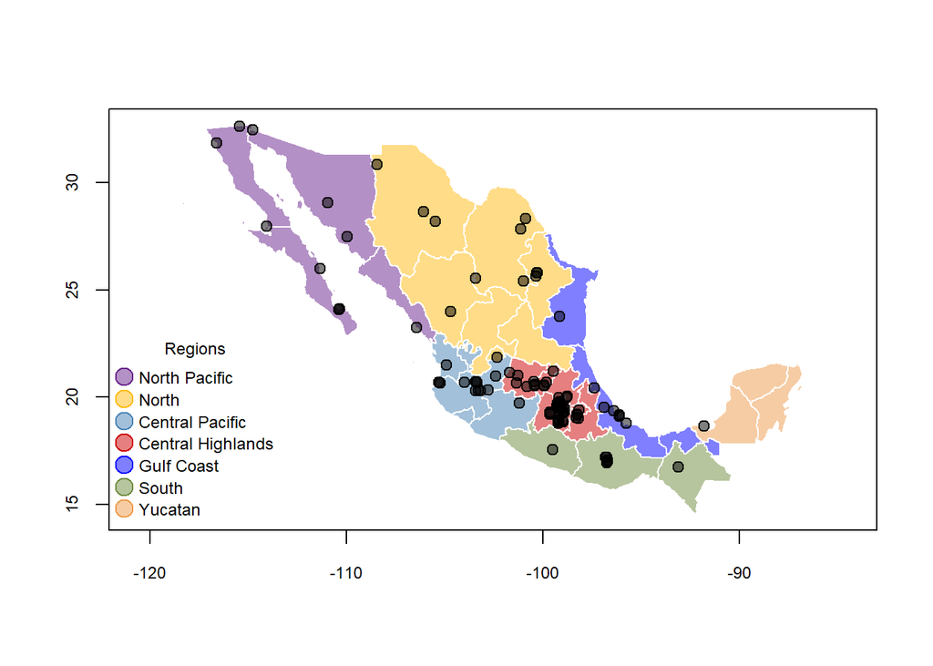

```r
plot.new()
#svg("SVGfig.MAP.sightsXregionWlit.cities.svg", width=7, height=6)
plot(mx.shapes,col=alpha(all.states$col.names, 0.5), border = 'white')
map.axes(cex.axis=0.75)

#plot city location where observations reported any time 1999-2015, use average lat/long for obs X city
points(avg.city.loc.MASTER$avg.cityLOG,avg.city.loc.MASTER$avg.cityLAT, #LONG. goes 1st
       col=alpha("black", 0.9),
       bg=alpha("black", 0.5), pch=21, cex=1.1)

#add extra cities not on citizen science data, but ARE in cited literature
points(lit.cities$long,lit.cities$lat, #LONG. goes 1st
       col=alpha("black", 0.9),
       bg=alpha("black", 0.5), pch=21, cex=1.1)


#reg7.master #for legend
legdtxt <- reg7.master$reg7.cat
legdcol <- reg7.master$col.names

legend("bottomleft", # position
       legend = legdtxt,
       title = "Regions",
       cex = 0.75,
       pch=21,
       pt.cex = 1.8,
       col = alpha(legdcol, 1), pt.bg = alpha(legdcol, 0.5),
       bty = "n",
       y.intersp=1.1)
```

```r
#dev.off()
```

# FIGURE 3: dotplot of observations by city (grouped by region)

## prepare data

```r
#now add this new y-coord back to dcasted cit.sci data above and re-melt?
# use MELT.citiesXyrs.no0s from above, need all cit.sci data = TRUE match (don't need all MASTER cities to match, use that to plot axes/text)
MELT.citiesXyrs.no0s.wPLOTORD <- merge(MELT.citiesXyrs.no0s, MASTER.cities.CSciXcites.Wstates.Wreg7s, by=c("city", "state"), all.x=TRUE)

#check # records should be same -- looks good! both 175 records
str(MELT.citiesXyrs.no0s)
```

```
## 'data.frame':    175 obs. of  4 variables:
##  $ state           : Factor w/ 25 levels "Aguascalientes",..: 1 1 2 2 2 2 2 2 3 3 ...
##  $ city            : Factor w/ 93 levels "Aguascalientes",..: 1 1 28 28 28 28 50 50 13 25 ...
##  $ year            : num  2014 2015 2012 2013 2014 ...
##  $ num.reportsXcity: num  3 3 1 2 2 6 1 1 1 2 ...
```

```r
str(MELT.citiesXyrs.no0s.wPLOTORD) #use this now to plot dotplot (has new y coords to allow extra lines for citation-only reported cities)
```

```
## 'data.frame':    175 obs. of  10 variables:
##  $ city                : Factor w/ 93 levels "Aguascalientes",..: 1 1 2 3 4 5 6 7 8 9 ...
##  $ state               : Factor w/ 25 levels "Aguascalientes",..: 1 1 12 12 7 25 13 24 17 25 ...
##  $ year                : num  2014 2015 2014 2015 2015 ...
##  $ num.reportsXcity    : num  3 3 1 4 1 3 2 1 1 1 ...
##  $ reg7.cat            : chr  "North" "North" "Central Pacific" "Central Pacific" ...
##  $ ord                 : int  1 1 13 13 7 30 14 29 19 30 ...
##  $ reg.order           : int  2 2 3 3 2 5 4 4 2 5 ...
##  $ col.names           : Factor w/ 7 levels "blue","darkgoldenrod1",..: 2 2 6 6 2 1 5 5 2 1 ...
##  $ names.w.accents     : chr  "Aguascalientes" "Aguascalientes" "Jalisco" "Jalisco" ...
##  $ yPlot.ord.CSciXcites: int  12 12 24 25 16 82 44 78 21 83 ...
```

```r
#find unique x axis (years)
year.labs <- as.data.frame(unique(MELT.citiesXyrs.no0s.wPLOTORD$year))
names(year.labs) <- "year"
year.labs <- arrange(year.labs, year)
str(year.labs)
```

```
## 'data.frame':    12 obs. of  1 variable:
##  $ year: num  1999 2005 2006 2007 2008 ...
```

```r
#unique(df[c("yad", "per")])
city.labs.new <- unique(MELT.citiesXyrs.no0s.wPLOTORD[c("yPlot.ord.CSciXcites", "city")])
city.labs.new <- arrange(city.labs.new, yPlot.ord.CSciXcites) #sort by y axis coords
length(MASTER.cities.CSciXcites.Wstates.Wreg7s$city)
```

```
## [1] 97
```

```r
#get all 7 regions with avg reg.order to add reg labels at right spots as axis labels
GRxreg.plotlabs <- group_by(MELT.citiesXyrs.no0s.wPLOTORD, reg7.cat, reg.order)
SUMxreg.plotlabs <- as.data.frame(summarise(GRxreg.plotlabs, avg.reg.plot.ord=mean(yPlot.ord.CSciXcites)))
SUMxreg.plotlabs <- arrange(SUMxreg.plotlabs, reg.order)
str(SUMxreg.plotlabs)
```

```
## 'data.frame':    7 obs. of  3 variables:
##  $ reg7.cat        : chr  "North Pacific" "North" "Central Pacific" "Central Highlands" ...
##  $ reg.order       : int  1 2 3 4 5 6 7
##  $ avg.reg.plot.ord: num  5.38 17.63 30.41 58.54 85.33 ...
```

## PLOT DOTPLOT

```r
#START PLOT CITIES ON Y
plot.new()
#setwd("C:/Users/ehobs/Dropbox/P-monk MX invasion/MX-Monks/PLOTS/")
#svg("SVGfig.DOTPLOT.sightsXcityXregionWlegnd.Wcitations.svg", width=9, height=11.5)

par(mar=c(5,8,3,12))

plot(MELT.citiesXyrs.no0s.wPLOTORD$year, MELT.citiesXyrs.no0s.wPLOTORD$yPlot.ord.CSciXcites, type="p", axes=F,
     ylim=rev(c(1,length(MASTER.cities.CSciXcites.Wstates.Wreg7s$city))), xlim=c(min(year.labs$year), max(year.labs$year)),
     xlab="Year", ylab=NA,
     pch=21, col=alpha(MELT.citiesXyrs.no0s.wPLOTORD$col.names, 0.9), bg=alpha(MELT.citiesXyrs.no0s.wPLOTORD$col.names, 0.4),
     cex=log(MELT.citiesXyrs.no0s.wPLOTORD$num.reportsXcity)+0.5
)
#ADD LITERATURE POINTS
#points(x=1999, y=52, col="red")

#ADD AXES

axis(4, at=rev(1:length(MASTER.cities.CSciXcites.Wstates.Wreg7s$city)),
     labels=rev(MASTER.cities.CSciXcites.Wstates.Wreg7s$city), las=2, cex.axis=0.6)
axis(1, at=seq(min(year.labs$year), max(year.labs$year)),
     labels=seq(min(year.labs$year), max(year.labs$year), by=1),
     las=2, cex.axis=1)
#add region labels
axis(2, at=rev(c(SUMxreg.plotlabs$avg.reg.plot.ord)), labels=rev(SUMxreg.plotlabs$reg7.cat),
     las=2, cex.axis=1, lwd.tick=0)

# add lines for start of ban
abline(v=2008, lty=1, col=alpha("grey", 0.6), lwd=2)
box()

#add text for citations
# use locXyrs.citations.Y

text(x=locXyrs.citations.wCOORDS$year.sighted, y=locXyrs.citations.wCOORDS$yPlot.ord.CSciXcites,
     labels=locXyrs.citations.wCOORDS$cite.id, col="black",
     cex=0.6)
#col=locXyrs.citations.wCOORDS$col.names,

#add first report (1994-1995 somewhere, in MX City) as 1998.5, then add note for real year
text(x=1998.5, y=62,
     labels="A", col="black",
     cex=0.6)

#add key for point sizes
legdtxt <- c("1", "10", "100")
legdptcex <- log(as.numeric(c("1", "10", "100")))+0.5

legend("bottomleft", # position
       legend = legdtxt,
       title = "Number of reports",
       cex = 0.9,
       pch=21,
       pt.cex = legdptcex,
       col = alpha("grey", 0.9), pt.bg = alpha("grey", 0.6),
       bty = "n",
       y.intersp=1.1)

#add colored lines in margin for regions
GR.reg.maxmin.Y <- group_by(MELT.citiesXyrs.no0s.wPLOTORD, reg7.cat, reg.order)
SUM.reg.maxmin.Y <- as.data.frame(summarise(GR.reg.maxmin.Y,
                                                  min.Y=min(yPlot.ord.CSciXcites)-0.3,
                                                  max.Y=max(yPlot.ord.CSciXcites)+0.3
                                                  ))
SUM.reg.maxmin.Y
```

```
##            reg7.cat reg.order min.Y max.Y
## 1 Central Highlands         4  37.7  80.3
## 2   Central Pacific         3  23.7  36.3
## 3        Gulf Coast         5  80.7  88.3
## 4             North         2  11.7  23.3
## 5     North Pacific         1   0.7  11.3
## 6             South         6  88.7  96.3
## 7           Yucatan         7  96.7  97.3
```

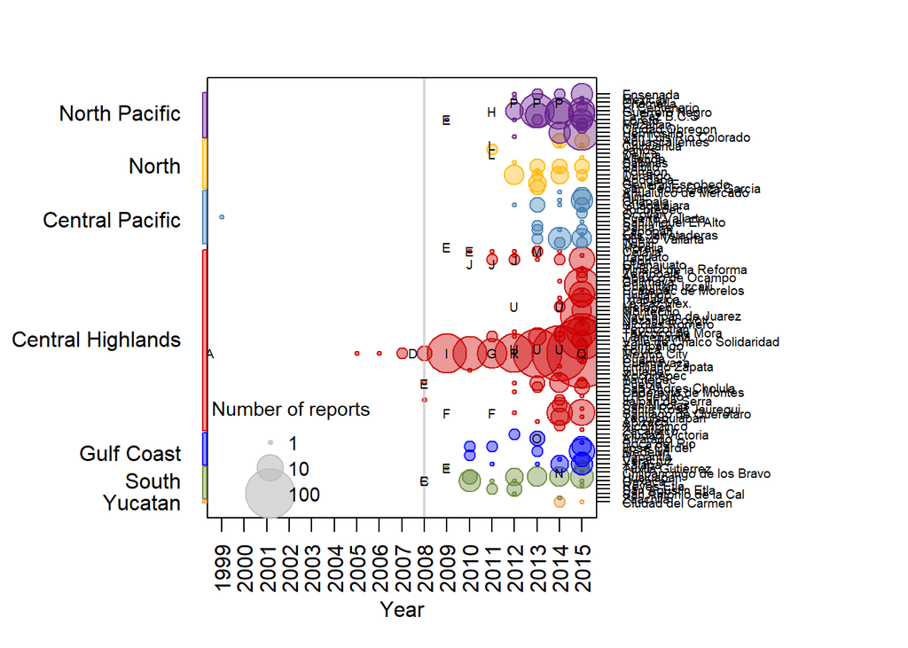

```r
SUM.reg.maxmin.Y$x <- 1998

#merge colors from master with point locations
SUM.reg.maxmin.Y <- merge(SUM.reg.maxmin.Y, select(reg7.master, reg7.cat, col.names), by="reg7.cat")
SUM.reg.maxmin.Y <- arrange(SUM.reg.maxmin.Y, reg.order)

#add rectangles
rect(xleft=1998.25-0.1, ybottom=SUM.reg.maxmin.Y$min.Y,
     xright=1998.25+0.1, ytop=SUM.reg.maxmin.Y$max.Y,
     col = alpha(SUM.reg.maxmin.Y$col.names,0.4), border = alpha(SUM.reg.maxmin.Y$col.names,0.9), lty = 1, lwd = 1, xpd=TRUE)
```

```r
#dev.off()
```